# Math 534 Midterm 1

Jose Luis Gonzalez

3/11/2018

### Problem 1

A scientist studied the effects of a very strong storm in trees in a forest in Minnesota as a function of the tree diameters and the severity of winds in the areas where the trees were located. The data for $n$ = 659 trees are given at: http://mathfaculty.fullerton.edu/mori/data/math534/blowBF.txt

$$\begin{aligned}
D &= \text{Diamter of the tree.}\\
S &= \text{Severity of the storm at the location of the tree in the scale of 0 to 1, with 1 being most severe.} \\
y &= \text{0 if the tree survived and 1 if the tree is blown down.}\\
\end{aligned}$$

Here, $y_1 , \dots , y_n$ is a set of $n$ observations where $y_i$ ~ $Bernoulli(\pi_i)$. We are to estimate $\pi_i = P(y_i = 1)$, the probability that a tree is blown down, as a function of $D$ and $S$. In particular we parameterize this probability by the logit funciton:

$$\pi_i(\beta) = \frac{\exp(x_{i}^{T}\beta)}{1 + \exp(x_{i}^{T}\beta)} \space\space \text{for i} = 1,\dots, n$$

where $x_{i}^{T}$ = $(x_{i1}, x_{i2}, x_{i3})$, where $x_{i1} = 1$ is the intercept, $x_{i2} = log(D)$, and $x_{i3} = S$, and $\beta (\beta_1,\beta_2, \beta_3)^{T}$ is a set of 3 parameters to be estimated.

#### (a) Write the log-likelihood function $\ell(\beta)$ as a function of $y_{i}$’s and $\pi_i(\beta)$.

$$\begin{aligned}
\ell(\beta) &= \sum_{i=1}^{n} y_i\log(\pi_i(\beta)) + (1-y_i)\log(1 - \pi_i(\beta)) \\
&= \sum_{i=1}^{n} y_i [x_{i}^{T}\beta - \log(1 + \exp(x_{i}^{T}\beta))] + (1-y_i)\log\left(1-\frac{\exp(x_{i}^{T}\beta)}{1+\exp(x_{i}^{T}\beta)}\right)
\end{aligned}$$

#### (b) Obtain the first differential $d\pi_i(d\beta)$ and the second differential $dd\pi_i(d\beta,d\beta)$.

First differential of $\pi_i(\beta)$: $d\pi_i(d\beta)$

$$d\pi_i(d\beta) = \frac{x_{i}^{T}d\beta e^{(x_{i}^{T}\beta)}}{(1 + e^{(x_{i}^{T}\beta)})^{2}}$$

Second differential of $\pi_i(\beta)$: $dd\pi_i(d\beta, d\beta)$
$$dd\pi_i(d\beta,d\beta) = \frac{x_{i}^{T}d\beta x_{i}^{T}d\beta e^{(x_{i}^{T}\beta)}}{(1 + e^{(x_{i}^{T}\beta)})^{2}} - \frac{2x_{i}^{T}d\beta x_{i}^{T}d\beta e^{(2x_{i}^{T}\beta)}}{(1 + e^{(x_{i}^{T}\beta)})^{3}}$$

#### (c) Obtain the first differential $d\ell(d\beta)$ and use it to derive formulas for $\partial\ell(\beta)/\partial\beta_i$ for i = 1,2,3.

$$\begin{aligned}
d\ell(d\beta) &= \sum_{i = 1}^{n} \left[y_i\frac{1}{1+e^{x_{i}^{T}\beta}}x_{i}^{T}d\beta - (1-y_i)\frac{e^{x_{i}^{T}\beta}}{1+e^{x_{i}^{T}\beta}}x_{i}^{T}d\beta\right]\\
&= \sum_{i = 1}^{n} (y_i - \frac{e^{x_{i}^{T}\beta}}{1+e^{x_{i}^{T}\beta}})x_{i}^{T}d\beta\\
&= \sum_{i =1}^{n} (y_i - \pi_i(\beta))x_{i}^{T}d\beta = V d\beta
\end{aligned}$$
where, $V = \sum_{i =1}^{n} (y_i - \pi_i(\beta))x_{i}^{T}$ is a 1 x 3 row vector. This implies that the formulas for $\partial\ell(\beta)/\partial\beta_i$’s are:
$$\frac{\partial\ell(\beta)}{\partial\beta_i} = V_i \space, \space \text{for i} = 1,2,3$$

#### (d) Write an R code to implement steepest ascent method with step-halving to obtain the maximum likelihood estimates for $\beta$. Use modified relative error as a convergence criterion with threshold value of $10^{-4}$.

```r
datat <- read.table("http://mathfaculty.fullerton.edu/mori/data/math534/blowBF.txt", header = TRUE)
attach(datat)

n = length(datat$y)
X = cbind(rep(1, n), log(datat$D), datat$S)
Y = matrix(datat$y, nrow = n, ncol = 1)

# likelihood
likemvn <- function(datat, B){
  n = length(datat$y)
  X = cbind(rep(1, n), log(datat$D), datat$S)
  Y = matrix(datat$y, nrow = n, ncol = 1)

  sum = 0
  for( i in 1:n){
    ex <- as.numeric(exp(X[i,]%*%B)) # compute exp(X_iB) to avoid clunkiness
    sumnd <- Y[i]*log(ex/(1+ex)) + (1-Y[i])*(log(1-(ex/(1 +ex))))
    sum = sum + sumnd
  }
  l = sum
  grad = grad(X,B,n) # computes gradient using function line 27
  list(l = l, grad = grad)
}

# gradient
grad = function(X,B,n){
  sumg = 0
  for(i in 1:n){
    ex <- as.numeric(exp(X[i,]%*%B))
    sumndg <- (Y[i] - ex/(1+ex))*X[i,]
    sumg = sumg + sumndg
  }
  sumg <- matrix(sumg, 3,1)
  return(sumg)
}


# steepest ascent
optmstp <- function(datat, B, maxit){
  it = 0
  condition = FALSE
  res <- list() # creating list to store values
  while(it < maxit & condition == FALSE){
    like = rep("NA", 22)
    grad_norm = rep("NA", 22)
    it = it + 1
    halve = 0

    a = likemvn(datat, B)
    like[1] <- formatC(a$l, digits =4, format = "f") # Storing formatted version of likelihood at B_0
    grad_norm[1] <- format(norm(a$grad, type = "2"), scientific = TRUE, digits =2) # Storing formatted version of gradient at B_0
    B1 = B + a$grad # Steepest Ascent
    atmp = likemvn(datat, B1)

    # Following prevents the function from stopping if it approaches NaNs
    while(is.nan(atmp$l) == TRUE & halve <20){
      halve = halve + 1
      B1 = B + a$grad/2^halve
      atmp = likemvn(datat, B1)

    }
    like[halve+2] <- formatC(atmp$l, digits =4, format = "f")
    grad_norm[halve+2] <- format(norm(atmp$grad, type = "2"), scientific = TRUE, digits = 2)
    # Step-halving
    while(atmp$l < a$l & halve <20){
      halve = halve + 1
      B1 = B + a$grad/2^halve
      atmp = likemvn(datat, B1)
      like[halve+2] <- formatC(atmp$l, digits =4, format = "f")
      grad_norm[halve+2] <- format(norm(atmp$grad, type = "2"),scientific = TRUE, digits = 2)
    }
    mre_norm <- norm((B1-B)/pmax(1,abs(B1)), type = "I") # calcualtes MRE norm for last iteration
    if(halve >= 20){
      print(paste("Step Halving failed after 20 atempts", it))
      condition = TRUE
    }
    if(mre_norm <= 10^(-4)){
      print(paste('Convergence Criteria Met', mre_norm, it))
      condition = TRUE
    }
    values <- cbind(rep(it,length(halve +2)), cbind(c("NA",seq.int(0,halve))),
                    like[1:(halve +2)], grad_norm[1:(halve +2)],cbind(c(rep("NA", (halve +1)), mre_norm)))
    dimnames(values) <- list(rep("", (halve+2)),c("IT", "Halving","Log-Likelihood","||gradient||", "MRE"))
    res[[it]] <- values
    B = B1
  }
  print(res[1:5], quote = FALSE) # prints first 5
  print(res[(length(res)-2):length(res)], quote = FALSE) # prints last 3
  mleB <<- B1
}


B <- matrix(0,3,1)
maxit <- 1200
optmstp(datat, B, maxit)
```

```
## [1] "Convergence Criteria Met 8.30780454975805e-05 607"
## [[1]]
##  IT Halving Log-Likelihood ||gradient|| MRE
##  1  NA      -456.7840      1.7e+02      NA
##  1  0       -104399.5101   6.3e+02      NA
##  1  1       -52199.7551    6.3e+02      NA
##  1  2       -26099.8775    6.3e+02      NA
##  1  3       -13049.9388    6.3e+02      NA
##  1  4       -6524.9694     6.3e+02      NA
##  1  5       -3262.4913     6.3e+02      NA
##  1  6       -1632.9088     6.3e+02      NA
##  1  7       -845.4744      5.7e+02      NA
##  1  8       -533.3509      3.7e+02      NA
##  1  9       -451.1653      1.4e+02      0.274532877479257
##
```

[output cut: 91 more lines]

|  | MLE |
| --- | --- |
| b0 | -9.508914 |
| b1 | 3.177876 |
| b2 | 4.486720 |

#### (e) Obtain the second differential $dd\ell(d\beta,d\beta)$

$$d\ell(d\beta,d\beta) = \sum_{i =1}^{n} -x_{i}^{T}d\beta\left(\frac{e^{x_{i}^{T}\beta}}{(1+e^{x_{i}^{T}\beta})^2}\right)x_{i}^{T}d\beta$$

Let $W=\frac{e^{x_{i}^{T}\beta}}{(1+e^{x_{i}^{T}\beta})^2}$, where W is a scalar. Then a$-E[dd\ell(d\beta,d\beta)]$ is,

$$- E\left[\frac{\partial^{2}\ell}{\partial \beta_{k}\partial \beta_{l}}\right] = \sum_{i =1}^{n} x_{i}^{T}d\beta W x_{i}^{T}d\beta$$

Furthermore For $k = l$,

$$\frac{\partial^{2}\ell}{\partial \beta_{k}\partial \beta_{l}} = \sum_{i =1}^{n} -x_{ik}^{T} W x_{ik}^{T}$$

For $k \neq l$,

$$\frac{\partial^{2}\ell}{\partial \beta_{k}\partial \beta_{l}} = \sum_{i =1}^{n} -x_{ik}^{T} W x_{il}^{T}$$
In general, this implies that the Fisher Information Matrix elements are: For $k \neq l$ and $ k = l$,
$$- E\left[\frac{\partial^{2}\ell}{\partial \beta_{k}\partial \beta_{l}}\right] = \sum_{i =1}^{n} x_{ik}^{T} W x_{il}^{T}$$
We’ll only use this formula to compute our fisher information matrix because it is agreeable with both cases $k \neq l$ and $k = l$.

#### (g) Write an R code to implement the Fisher-scoring algorithm to obtain the maximum likelihood estimates for $\beta$. use modified relative error as a convergence criterion with threshold value $10^{-6}$.

```r
# Fisher Information Matrix
fish <- function(datat, B){
  n = length(datat$y)
  X = cbind(rep(1, n), log(datat$D), datat$S)
  Y = matrix(datat$y, nrow = n, ncol = 1)
f_mat <- matrix(0,3,3)
B <- matrix(0, 3,1)
for(k in 1:3){
  for(l in 1:3){
    for(i in 1:n){
      ex <- as.numeric(exp(X[i,]%*%B))
      sumnd <- X[i,k]*(ex/(1+ex))*X[i,l]
      f_mat[k,l] <- f_mat[k,l] + sumnd
      }
    }
  }
return(f_mat)
}

# Fisher-Scoring
optmfish <- function(datat, B, maxit){
  it = 0
  condition = FALSE
  res <- list()
  while(it < maxit & condition == FALSE){
    like = rep("NA", 22)
    grad_norm = rep("NA", 22)
    it = it + 1
    halve = 0

    a = likemvn(datat, B)
    like[1] <- formatC(a$l, digits =4, format = "f")
    grad_norm[1] <- format(norm(a$grad, type = "2"), scientific = TRUE, digits =2) # Storing formatted version of gradient at B_0

    # Fisher Info
    I = fish(datat,B)
    invI = solve(I)
    B1 = B + invI%*%a$grad


    atmp = likemvn(datat, B1)

    while(is.nan(atmp$l) == TRUE & halve <20){
      halve = halve + 1
      B1 = B + invI%*%a$grad/2^halve # Fisher Scoring
      atmp = likemvn(datat, B1)

    }
    like[halve+2] <- formatC(atmp$l, digits =4, format = "f")
    grad_norm[halve+2] <- format(norm(atmp$grad, type = "2"), scientific = TRUE, digits = 2)
    while(atmp$l < a$l & halve <20){
      halve = halve + 1
      B1 = B + Inv%*%a$grad/2^halve
      atmp = likemvn(datat, B1)
      like[halve+2] <- formatC(atmp$l, digits =4, format = "f")
      grad_norm[halve+2] <- format(norm(atmp$grad, type = "2"),scientific = TRUE, digits = 2)
    }
    mre_norm <- norm((B1-B)/pmax(1,abs(B1)), type = "I")
    if(halve >= 20){
      print(paste("Step Halving failed after 20 atempts", it))
      condition = TRUE
    }
    if(mre_norm <= 10^(-6)){
      print(paste('Convergence Criteria Met', mre_norm, it))
      condition = TRUE
    }
    values <- cbind(rep(it,length(halve +2)), cbind(c("NA",seq.int(0,halve))),
                    like[1:(halve +2)], grad_norm[1:(halve +2)],cbind(c(rep("NA", (halve +1)), mre_norm)))
    dimnames(values) <- list(rep("", (halve+2)),c("IT", "Halving","Log-Likelihood","||gradient||", "MRE"))
    res[[it]] <- values
    B = B1
  }
  print(res[1:5], quote = FALSE)
  print(res[(length(res)-2):length(res)], quote = FALSE)
  mleB <<- B1
}

B <- matrix(0,3,1)
maxit <- 1200
optmfish(datat,B,maxit)
```

```
## [1] "Convergence Criteria Met 9.74061166215013e-07 78"
## [[1]]
##  IT Halving Log-Likelihood ||gradient|| MRE
##  1  NA      -456.7840      1.7e+02      NA
##  1  0       -347.7468      9e+01        1
##
## [[2]]
##  IT Halving Log-Likelihood ||gradient|| MRE
##  2  NA      -347.7468      9e+01        NA
##  2  0       -314.6320      5.5e+01      0.348326346654852
##
## [[3]]
##  IT Halving Log-Likelihood ||gradient|| MRE
##  3  NA      -314.6320      5.5e+01      NA
##  3  0       -300.6367      3.7e+01      0.182343471553454
##
## [[4]]
##  IT Halving Log-Likelihood ||gradient|| MRE
##  4  NA      -300.6367      3.7e+01      NA
##  4  0       -293.4913      2.7e+01      0.114705559049553
##
## [[5]]
##  IT Halving Log-Likelihood ||gradient|| MRE
##  5  NA      -293.4913      2.7e+01      NA
##  5  0       -289.4290      2e+01        0.0794840532645471
##
## [[1]]
##  IT Halving Log-Likelihood ||gradient|| MRE
##  76 NA      -281.9505      4.3e-04      NA
##  76 0       -281.9505      3.8e-04      1.29565165419555e-06
##
## [[2]]
##  IT Halving Log-Likelihood ||gradient|| MRE
##  77 NA      -281.9505      3.8e-04      NA
##  77 0       -281.9505      3.3e-04      1.12340704889714e-06
##
## [[3]]
##  IT Halving Log-Likelihood ||gradient|| MRE
##  78 NA      -281.9505      3.3e-04      NA
##  78 0       -281.9505      2.8e-04      9.74061166215013e-07
```

|  | MLE |
| --- | --- |
| b0 | -9.562026 |
| b1 | 3.197544 |
| b2 | 4.508565 |

#### (h) What is the prediction of your model for the probability that a tree with a diameter 10 would blow down as a function of the severity of wind, as it ranges from 0 to 1. Show the probability using a graph, and comment.

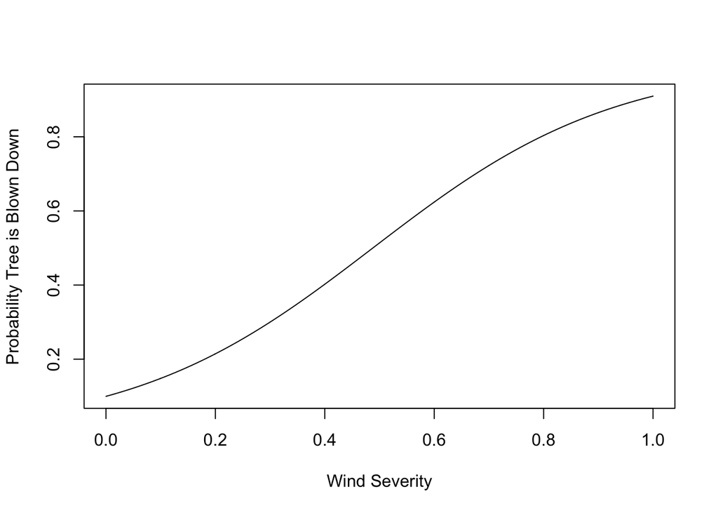

```r
s = seq(0,1, length.out = 1000) # range for wind severity
p = rep(NA, 1000) # vector for probabilities
for(i in 1:length(s)){
  x = matrix(c(1,log(10),s[i]),1,3) # severity is the only variable ranging from 0 to 1
  ex <- exp(x%*%mleB) # mleB is obtained from fisher-scoring
 p[i] = (ex/(1+ex)) # This is P(y_i = 1),
}
plot(s,p, type = 'l', xlab = "Wind Severity", ylab = "Probability Tree is Blown Down")
```

```r
d10 <- datat[which(datat$D == 10),]
pred = mean(d10[which(d10$S>=.7),]$y)
```

```r
pred = matrix(pred, 1,1, dimnames = list(c('Probabilty 10 Diameter Tree Falls'), c("Prediction")))
pred%>%
  kable()%>%
  kable_styling(full_width = F)
```

|  | Prediction |
| --- | --- |
| Probabilty 10 Diameter Tree Falls | 0.8333333 |

#### (i) What is the prediction of your model for the probability that a tree would blown down with wind severity 0.4 and diamters ranging from 5 to 30. Show the probability using a graph, and comment.

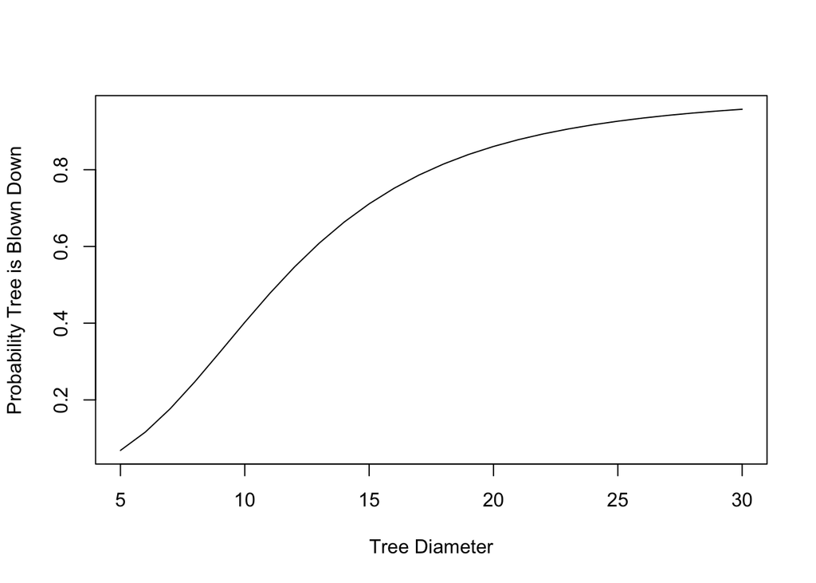

```r
d = seq(5,30)
p = rep(NA, length(d)) # range of tree diameter
for(i in 1:length(d)){
  x = matrix(c(1,log(d[i]),.4),1,3) # diameter is the only variable everything is is constant
  ex <- exp(x%*%mleB) # mle B is obtained from fisher information
  p[i] = (ex/(1+ex)) # This is P(y_i =1)
}
plot(d,p, type = 'l', xlab = "Tree Diameter", ylab = "Probability Tree is Blown Down")
```

```r
s40 <- datat[which(datat$S>= .39 & datat$S<=.41),]
pred = mean(s40[which(s40$y ==1),]$D)
```

```r
pred = matrix(pred, 1,1, dimnames = list(c('Avg. Diameter Fallen Tree for Severity .40'), c("Prediction")))
pred%>%
  kable()%>%
  kable_styling(full_width = F)
```

|  | Prediction |
| --- | --- |
| Avg. Diameter Fallen Tree for Severity .40 | 11.4 |

#### (j) Plot the three-dimensional graph of $\pi(\beta)$, using your maximum likelihood estimates and as a function of $X_1 = S$ and $X_2 = \log(D)$. For your plot, $X_1$ should range in the interval (0,1) and $X_2$ shoudl range in the range of the observed values for $\log(D)$. Moreover, draw the constant value contours and use it to explain how changing vaules of $S$ and $D$ effects the probability that a tree is blown down.

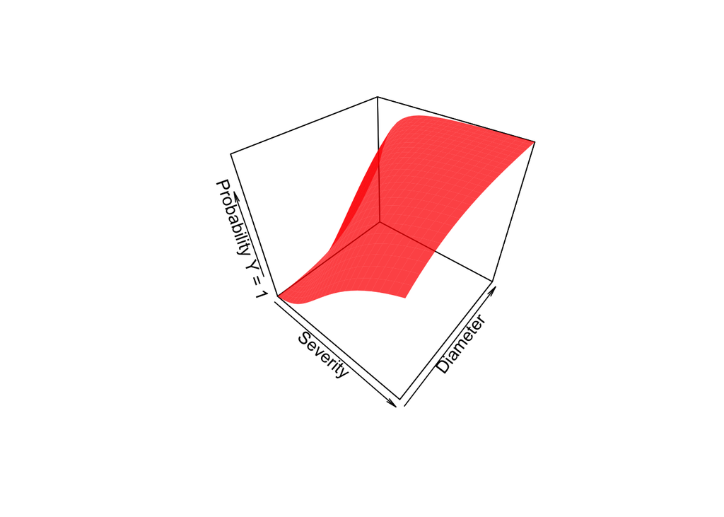

```r
d = seq(5,30)
s = seq(0,1,length.out = length(d))
prob <- function(d,s){
  len = length(d)
  r = numeric(length(len))
  mleB <- c(-9.562026, 3.197544, 4.508565)
  for(i in 1:len){
    x = matrix(c(1,log(d[i]),s[i]),1,3)
    ex <- exp(x%*%mleB)
    r[i] <- ex/(1+ex)
  }
  r
}

threed <- outer(d,s,prob)

library(plot3D)
persp3D(x = s, y = d , z = threed, col = "red", alpha = .5, xlab = "Severity", ylab = "Diameter", zlab = "Probability Y = 1", main = "")
```

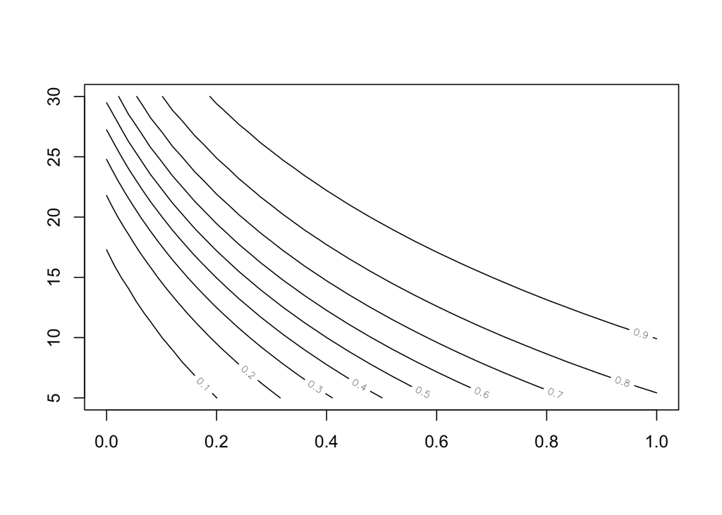

```r
contour(x = s,y = d,z = threed)
```